# Interaction QTL x Year

This file aims to provide more details concerning the QTL x Year interaction of the resistance of Durum Wheat to WSSMV. We are going to study the 2 phenotypes for which we have data in 2012 and 2015.

The study is done using the QTLRel library

```r
library(QTLRel)
library(xtable)
```

# Symptom Severity (SS)

## Load data

I load the genotyping matrix first.

```r
genotype<-read.table("/Users/holtz/Dropbox/Publi_Mosaique/DATA/DATA/GROUPED/genotypage.csv", sep = ";" , header = F, na.strings = "-")
genotype=as.matrix(genotype)
colnames(genotype)=genotype[1,]
genotype=as.data.frame(genotype[-1 , ])
names(genotype)[1]<-"geno"
print("--- Your genotyping matrix looks correct. Dimension of the matrix are :")
```

```
## [1] "--- Your genotyping matrix looks correct. Dimension of the matrix are :"
```

```r
print(dim(genotype))
```

```
## [1]  348 7342
```

```r
# I copy this matrix 2 times, since I read 2012 and 2015 together.
rownames(genotype)=genotype[,1]
genotype=genotype[,-1]
a=genotype ; rownames(a)=paste(rownames(a),"2012",sep="_")
b=genotype ; rownames(b)=paste(rownames(b),"2015",sep="_")
genotype=rbind(a,b)
```

Then the genetic map:

```r
map <- read.table("/Users/holtz/Dropbox/Publi_Mosaique/DATA/DATA/genetic_map.txt" , header=T , dec = ".", na.strings = "-" , check.names=F)
colnames(map) <- c("LG", "marqueur", "Distance","group_physique","Posi_physique")
rownames(map) <- map$marqueur
map$LG <- as.factor(map$LG)
print("--- Your genetic map looks correct. Dimension of the map are :")
```

```
## [1] "--- Your genetic map looks correct. Dimension of the map are :"
```

```r
print(dim(map))
```

```
## [1] 8568    5
```

```r
map=map[    , c(2,1,3,5)]
colnames(map)=c("snp","chr", "dist", "phyPos")
```

And finally the phenotyping matrix

```r
BLUP<-read.table("/Users/holtz/Dropbox/Publi_Mosaique/DATA/DATA/GROUPED/phenotypage.csv", header = TRUE, sep=";")
colnames(BLUP)[1]="geno"
print("--- Your Phenotyping matrix looks correct. Dimension of the matrix are :")
```

```
## [1] "--- Your Phenotyping matrix looks correct. Dimension of the matrix are :"
```

```r
print(dim(BLUP))
```

```
## [1] 396   6
```

```r
# Fichier de phénotypage modifié, il va falloir mettre la NV de 2012 et 2015 ensemble, avec une colonne année.
a=BLUP[, c(1,2)] ; a$year="2012" ; colnames(a)=c("geno", "NV_blup_AR1","year") ; #a[,2]=a[,2]/0.745  #
a[,2]=ifelse(substr(a$geno, 1,2)=="TT", a[,2]/0.66 , a[,2]/0.83)
b=BLUP[, c(1,4)] ; b$year="2015" ; colnames(b)=c("geno", "NV_blup_AR1", "year") ; #b[,2]=b[,2]/1.2   #
b[,2]=ifelse(substr(b$geno, 1,2)=="TT", b[,2]/1.2 , a[,2]/1.21)
BLUP=rbind(a,b)
rownames(BLUP)=paste( BLUP[,1], BLUP$year,sep="_")
BLUP=BLUP[,-1]
# Note: On peut garder les blups tels quels / ou les pondéré par la variance génet de chaque année moyennée sur les 2 pops / ou par la variance génet de chaque année et chaque pop.
```

## Prepare data

We need to have genotype and phenotype in the same order:

```r
Y=na.omit(BLUP)
Y=Y[which(rownames(Y)%in%rownames(genotype)) , ]
genotype=genotype[which(rownames(genotype)%in%rownames(Y)) , ]
genotype=genotype[ match(rownames(Y),rownames(genotype)) , ]
```

## Calculate kinship matrix

```r
# missing data
set.seed(3)
print("yoyoyoyoyoyoyoyoyo")
```

```
## [1] "yoyoyoyoyoyoyoyoyo"
```

```r
XNNA=genotype
my_fun=function(x){length(x[x=="A" & !is.na(x) ])/length(!is.na(x)) }
prop=apply(XNNA , 2 , my_fun)
for(i in c(1:ncol(XNNA))){
    aa=XNNA[,i][is.na(XNNA[,i])]
    bb=rbinom(length(aa),1,prob=prop[i])
    XNNA[,i][is.na(XNNA[,i])]=c("B","A")[bb+1]
    }

# Change "A" to "AA"
XNNA=as.matrix(XNNA)
XNNA[which(XNNA=="A")]<-"AA"
XNNA[which(XNNA=="B")]<-"BB"

# Kinship matrix
K<-genMatrix(XNNA)

# I = identity matrix
I<-diag(nrow(Y))
```

## Markers effect

We compute a complete modele in QTLRel including year effect, marker effect and interaction between both.This model is computed marker per marker using the scanOne function. We compare the likelihood of this model with the model that does not include any marker, what gives us the marker effect trough its LOD score.

```r
mod1<-estVC(y=Y$NV_blup_AR1, x=Y$year, v=list(AA=K$AA,DD=NULL,HH=NULL,AD=NULL,MH=NULL,EE=I))
llk.hk2 <- scanOne(y=Y$NV_blup_AR1, vc=mod1, intcovar=Y$year, gdat=XNNA ,test="Chisq")
```

Manhattan plot to visualize the effect of each marker.

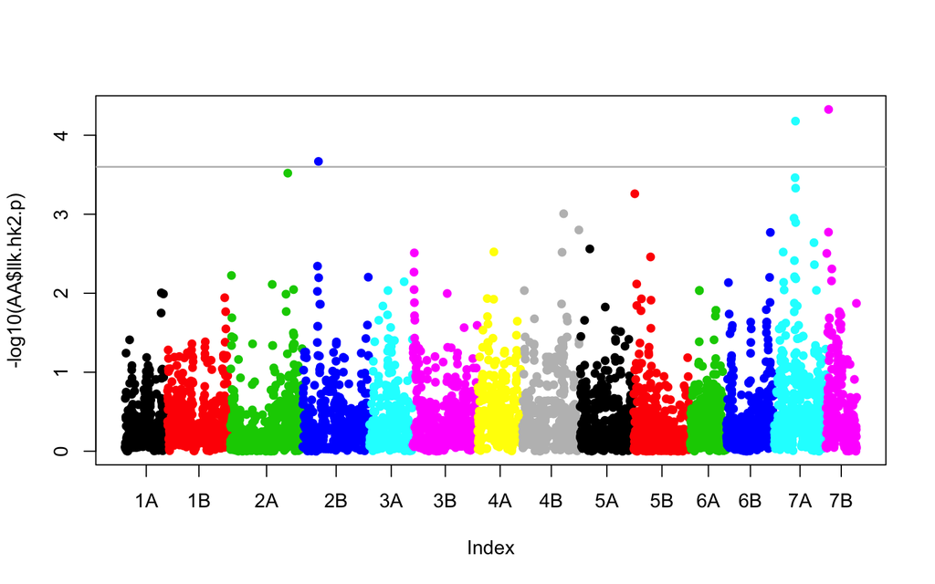

```r
# Merge LODs with the genetic map
AA=merge(map,data.frame( names(llk.hk2$p) , llk.hk2$p), by.x=1 , by.y=1, all.x=T)
AA=AA[order(AA$chr, AA$dist) , ]
AA=AA[!is.na(AA$llk.hk2.p) , ]
# And plot it
plot(-log10(AA$llk.hk2.p) , pch=20 , col=as.numeric(AA$chr) , cex=1.3, xaxt="n" )
abline(h=3.6, col="grey", lwd=1.5)
num=seq(1,nrow(AA))
num=aggregate(num, by=list(AA$chr), mean , na.rm=T)
axis(1, at=num[,2], labels=num[,1])
```

Summary of the significant markers:

```r
to_print=AA[-log10(AA$llk.hk2.p)>3.61 , ]
```

| snp | chr | dist | phyPos | llk.hk2.p |
| --- | --- | --- | --- | --- |
| Cluster_10786\|Contig2\|original@200 | 2B | 117.80 | 44285664 | 0.00 |
| Cluster_5672\|Contig1\|likelySeq@976 | 7A | 116.90 | 54995067 | 0.00 |
| Cluster_11106\|Contig2\|original@1147 | 7B | 19.00 | NA | 0.00 |

## Interaction effect.

We can also check for which marker the **interaction** effect was significant?

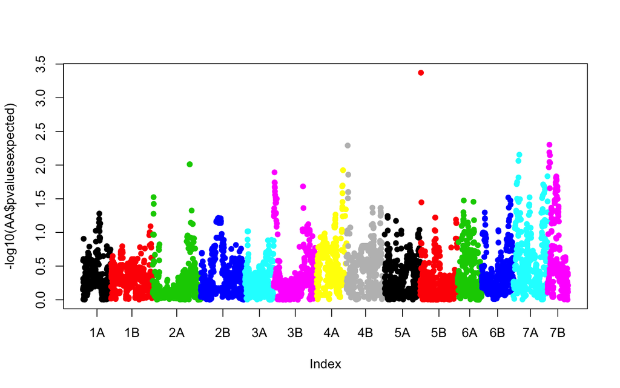

```r
#Compute 2 models: one with interaction, one without interaction
llk.hk_inter1 <-scanOne(y=Y$NV_blup_AR1, x=Y$year, vc=mod1, gdat=XNNA ,test="None")
llk.hk_inter2 <- scanOne(y=Y$NV_blup_AR1, vc=mod1, intcovar=Y$year, gdat=XNNA ,test="None")

# Find pvalue of each marker for interaction significance
diff_deviance <- llk.hk_inter2$p - llk.hk_inter1$p
pvaluesexpected=1-pchisq(diff_deviance, 1)

# Merge with map
AA=merge(map,data.frame( names(pvaluesexpected) , pvaluesexpected), by.x=1 , by.y=1, all.x=T)
AA=AA[order(AA$chr, AA$dist) , ]
AA=AA[!is.na(AA$pvaluesexpected) , ]

# Plot
plot(-log10(AA$pvaluesexpected) , pch=20 , col=as.numeric(AA$chr) , cex=1.3, xaxt="n" )
abline(h=3.6, col="grey", lwd=1.5)
num=seq(1,nrow(AA))
num=aggregate(num, by=list(AA$chr), mean , na.rm=T)
axis(1, at=num[,2], labels=num[,1])
```

# Elisa

## Load data

I load the genotyping matrix first.

```r
genotype<-read.table("/Users/holtz/Dropbox/Publi_Mosaique/DATA/DATA/GROUPED/genotypage.csv", sep = ";" , header = F, na.strings = "-")
genotype=as.matrix(genotype)
colnames(genotype)=genotype[1,]
genotype=as.data.frame(genotype[-1 , ])
names(genotype)[1]<-"geno"
print("--- Your genotyping matrix looks correct. Dimension of the matrix are :")
```

```
## [1] "--- Your genotyping matrix looks correct. Dimension of the matrix are :"
```

```r
print(dim(genotype))
```

```
## [1]  348 7342
```

```r
# I copy this matrix 2 times, since I read 2012 and 2015 together.
rownames(genotype)=genotype[,1]
genotype=genotype[,-1]
a=genotype ; rownames(a)=paste(rownames(a),"2012",sep="_")
b=genotype ; rownames(b)=paste(rownames(b),"2015",sep="_")
genotype=rbind(a,b)
```

Then the genetic map:

```r
map <- read.table("/Users/holtz/Dropbox/Publi_Mosaique/DATA/DATA/genetic_map.txt" , header=T , dec = ".", na.strings = "-" , check.names=F)
colnames(map) <- c("LG", "marqueur", "Distance","group_physique","Posi_physique")
rownames(map) <- map$marqueur
map$LG <- as.factor(map$LG)
print("--- Your genetic map looks correct. Dimension of the map are :")
```

```
## [1] "--- Your genetic map looks correct. Dimension of the map are :"
```

```r
print(dim(map))
```

```
## [1] 8568    5
```

```r
map=map[    , c(2,1,3,5)]
colnames(map)=c("snp","chr", "dist", "phyPos")
```

And finally the phenotyping matrix

```r
BLUP<-read.table("/Users/holtz/Dropbox/Publi_Mosaique/DATA/DATA/GROUPED/phenotypage.csv", header = TRUE, sep=";")
colnames(BLUP)[1]="geno"
print("--- Your Phenotyping matrix looks correct. Dimension of the matrix are :")
```

```
## [1] "--- Your Phenotyping matrix looks correct. Dimension of the matrix are :"
```

```r
print(dim(BLUP))
```

```
## [1] 396   6
```

```r
# Put ELisa2012 and 2015 together
a=BLUP[, c(1,3)] ; a$year="2012" ; colnames(a)=c("geno", "Elisa_blup_AR1","year") ; #a[,2]=a[,2]/0.745  #
a[,2]=ifelse(substr(a$geno, 1,2)=="TT", a[,2]/0.08373045 , a[,2]/ 0.07145543)
b=BLUP[, c(1,5)] ; b$year="2015" ; colnames(b)=c("geno", "Elisa_blup_AR1", "year") ; #b[,2]=b[,2]/1.2   #
b[,2]=ifelse(substr(b$geno, 1,2)=="TT", b[,2]/0.14488006 , a[,2]/0.13135315)
BLUP=rbind(a,b)
rownames(BLUP)=paste( BLUP[,1], BLUP$year,sep="_")
BLUP=BLUP[,-1]
# Note: On peut garder les blups tels quels / ou les pondéré par la variance génet de chaque année moyennée sur les 2 pops / ou par la variance génet de chaque année et chaque pop.
```

## Prepare data

We need to have genotype and phenotype in the same order:

```r
Y=na.omit(BLUP)
Y=Y[which(rownames(Y)%in%rownames(genotype)) , ]
genotype=genotype[which(rownames(genotype)%in%rownames(Y)) , ]
genotype=genotype[ match(rownames(Y),rownames(genotype)) , ]
```

## Calculate kinship matrix

```r
# missing data
set.seed(123)
XNNA=genotype
my_fun=function(x){length(x[x=="A" & !is.na(x) ])/length(!is.na(x)) }
prop=apply(XNNA , 2 , my_fun)
for(i in c(1:ncol(XNNA))){
    aa=XNNA[,i][is.na(XNNA[,i])]
    bb=rbinom(length(aa),1,prob=prop[i])
    XNNA[,i][is.na(XNNA[,i])]=c("B","A")[bb+1]
    }

# Change "A" to "AA"
XNNA=as.matrix(XNNA)
XNNA[which(XNNA=="A")]<-"AA"
XNNA[which(XNNA=="B")]<-"BB"

# Kinship matrix
K<-genMatrix(XNNA)

# I = identity matrix
I<-diag(nrow(Y))
```

## Markers effect

We compute a complete modele in QTLRel including year effect, marker effect and interaction between both.This model is computed marker per marker using the scanOne function. We compare the likelihood of this model with the model that does not include any marker, what gives us the marker effect trough its LOD score.

```r
mod1<-estVC(y=Y$Elisa_blup_AR1, x=Y$year, v=list(AA=K$AA,DD=NULL,HH=NULL,AD=NULL,MH=NULL,EE=I))
llk.hk2 <- scanOne(y=Y$Elisa_blup_AR1, vc=mod1, intcovar=Y$year, gdat=XNNA ,test="Chisq")
```

Manhattan plot to visualize the effect of each marker.

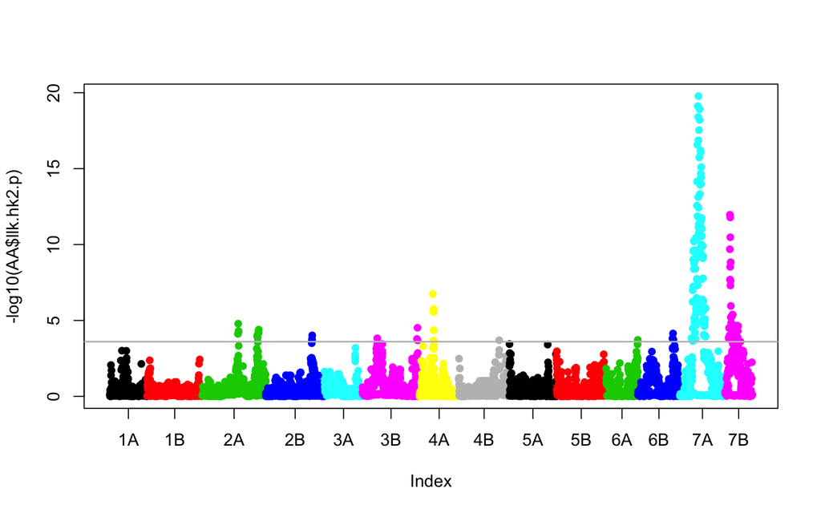

```r
# Merge LODs with the genetic map
AA=merge(map,data.frame( names(llk.hk2$p) , llk.hk2$p), by.x=1 , by.y=1, all.x=T)
AA=AA[order(AA$chr, AA$dist) , ]
AA=AA[!is.na(AA$llk.hk2.p) , ]
# And plot it
plot(-log10(AA$llk.hk2.p) , pch=20 , col=as.numeric(AA$chr) , cex=1.3, xaxt="n" )
abline(h=3.6, col="grey", lwd=1.5)
num=seq(1,nrow(AA))
num=aggregate(num, by=list(AA$chr), mean , na.rm=T)
axis(1, at=num[,2], labels=num[,1])
```

Summary of the significant markers:

```r
to_print=AA[-log10(AA$llk.hk2.p)>3.61 , ]
```

| snp | chr | dist | phyPos | llk.hk2.p |
| --- | --- | --- | --- | --- |
| Cluster_7162\|Contig2\|original@1017 | 2A | 128.30 | 97625839 | 0.00 |
| Cluster_9879\|Contig3\|original@840 | 2A | 128.50 | 58739239 | 0.00 |
| Cluster_14\|Contig1154\|likelySeq@75 | 2A | 128.80 | 188094959 | 0.00 |
| Cluster_4400\|Contig2\|original@1381 | 2A | 128.80 | 193166081 | 0.00 |
| Cluster_6528\|Contig11\|original@1883 | 2A | 214.70 | 238597423 | 0.00 |
| Cluster_8512\|Contig1\|complementarySeq@257 | 2A | 214.70 | 237335570 | 0.00 |
| Cluster_15067\|Contig1\|likelySeq@499 | 2A | 215.20 | 240647337 | 0.00 |
| Cluster_13791\|Contig2\|original@722 | 2A | 215.70 | 239251429 | 0.00 |
| Cluster_7251\|Contig1\|original@542 | 2A | 222.30 | 241261329 | 0.00 |
| Cluster_776\|Contig1\|original@1843 | 2A | 222.60 | 324791668 | 0.00 |
| Cluster_9605\|Contig2\|original@117 | 2A | 222.60 | 237744501 | 0.00 |
| Cluster_531\|Contig14\|original@680 | 2B | 219.90 | 306329232 | 0.00 |
| Cluster_1164\|Contig6\|original@275 | 2B | 221.10 | 316157194 | 0.00 |
| Cluster_14976\|Contig3\|likelySeq@997 | 2B | 221.50 | 312467834 | 0.00 |
| Cluster_8469\|Contig2\|original@15 | 3B | 95.90 | 172518916 | 0.00 |
| Cluster_7805\|Contig1\|likelySeq@873 | 3B | 262.90 | NA | 0.00 |
| Cluster_12325\|Contig3\|original@767 | 3B | 263.70 | 768812970 | 0.00 |
| Cluster_13366\|Contig1\|original@369 | 3B | 263.90 | 770579648 | 0.00 |
| Cluster_5280\|Contig3\|original@650 | 4A | 77.20 | 80842603 | 0.00 |
| Cluster_3382\|Contig3\|original@2012 | 4A | 77.60 | 83375384 | 0.00 |
| Cluster_3382\|Contig5\|original@1340 | 4A | 77.60 | 265099483 | 0.00 |
| Cluster_6022\|Contig2\|original@134 | 4A | 77.60 | NA | 0.00 |
| Cluster_1637\|Contig7\|original@210 | 4A | 80.10 | 38159085 | 0.00 |
| Cluster_7718\|Contig1\|complementarySeq@1275 | 4B | 129.10 | NA | 0.00 |
| Cluster_6106\|Contig1\|original@395 | 6A | 208.70 | 206547009 | 0.00 |
| Cluster_6239\|Contig3\|likelySeq@1424 | 6B | 158.20 | 196628320 | 0.00 |
| Cluster_3610\|Contig1\|original@2259 | 6B | 159.60 | 188411983 | 0.00 |
| Cluster_8700\|Contig2\|original@279 | 6B | 160.70 | NA | 0.00 |
| Cluster_10035\|Contig16\|likelySeq@534 | 7A | 71.30 | 120589124 | 0.00 |
| Cluster_16996\|Contig1\|original@443 | 7A | 88.80 | 22572000 | 0.00 |

[output cut: 154 more lines]

## Interaction effect.

We can also check for which marker the **interaction** effect was significant?

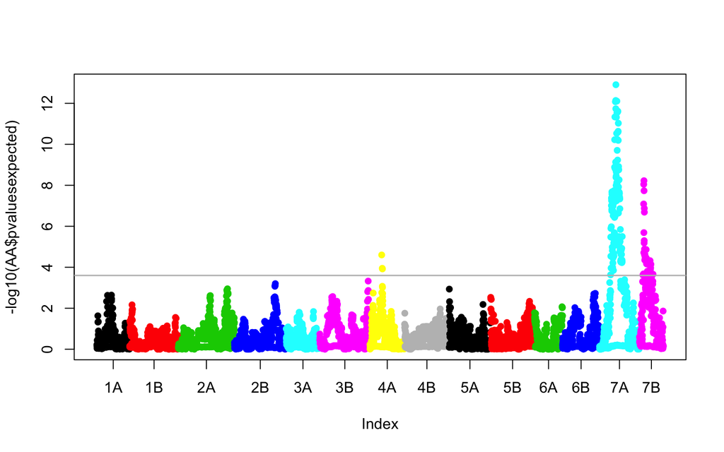

```r
#Compute 2 models: one with interaction, one without interaction
llk.hk_inter1 <-scanOne(y=Y$Elisa_blup_AR1, x=Y$year, vc=mod1, gdat=XNNA ,test="None")
llk.hk_inter2 <- scanOne(y=Y$Elisa_blup_AR1, vc=mod1, intcovar=Y$year, gdat=XNNA ,test="None")

# Find pvalue of each marker for interaction significance
diff_deviance <- llk.hk_inter2$p - llk.hk_inter1$p
pvaluesexpected=1-pchisq(diff_deviance, 1)

# Merge with map
AA=merge(map,data.frame( names(pvaluesexpected) , pvaluesexpected), by.x=1 , by.y=1, all.x=T)
AA=AA[order(AA$chr, AA$dist) , ]
AA=AA[!is.na(AA$pvaluesexpected) , ]

# Plot
plot(-log10(AA$pvaluesexpected) , pch=20 , col=as.numeric(AA$chr) , cex=1.3, xaxt="n" )
abline(h=3.6, col="grey", lwd=1.5)
num=seq(1,nrow(AA))
num=aggregate(num, by=list(AA$chr), mean , na.rm=T)
axis(1, at=num[,2], labels=num[,1])
```

# Symptom Severity (SS) - NO Blup normalization

## Load data

I load the genotyping matrix first.

```r
genotype<-read.table("/Users/holtz/Dropbox/Publi_Mosaique/DATA/DATA/GROUPED/genotypage.csv", sep = ";" , header = F, na.strings = "-")
genotype=as.matrix(genotype)
colnames(genotype)=genotype[1,]
genotype=as.data.frame(genotype[-1 , ])
names(genotype)[1]<-"geno"
print("--- Your genotyping matrix looks correct. Dimension of the matrix are :")
```

```
## [1] "--- Your genotyping matrix looks correct. Dimension of the matrix are :"
```

```r
print(dim(genotype))
```

```
## [1]  348 7342
```

```r
# I copy this matrix 2 times, since I read 2012 and 2015 together.
rownames(genotype)=genotype[,1]
genotype=genotype[,-1]
a=genotype ; rownames(a)=paste(rownames(a),"2012",sep="_")
b=genotype ; rownames(b)=paste(rownames(b),"2015",sep="_")
genotype=rbind(a,b)
```

Then the genetic map:

```r
map <- read.table("/Users/holtz/Dropbox/Publi_Mosaique/DATA/DATA/genetic_map.txt" , header=T , dec = ".", na.strings = "-" , check.names=F)
colnames(map) <- c("LG", "marqueur", "Distance","group_physique","Posi_physique")
rownames(map) <- map$marqueur
map$LG <- as.factor(map$LG)
print("--- Your genetic map looks correct. Dimension of the map are :")
```

```
## [1] "--- Your genetic map looks correct. Dimension of the map are :"
```

```r
print(dim(map))
```

```
## [1] 8568    5
```

```r
map=map[    , c(2,1,3,5)]
colnames(map)=c("snp","chr", "dist", "phyPos")
```

And finally the phenotyping matrix

```r
BLUP<-read.table("/Users/holtz/Dropbox/Publi_Mosaique/DATA/DATA/GROUPED/phenotypage.csv", header = TRUE, sep=";")
colnames(BLUP)[1]="geno"
print("--- Your Phenotyping matrix looks correct. Dimension of the matrix are :")
```

```
## [1] "--- Your Phenotyping matrix looks correct. Dimension of the matrix are :"
```

```r
print(dim(BLUP))
```

```
## [1] 396   6
```

```r
# Fichier de phénotypage modifié, il va falloir mettre la NV de 2012 et 2015 ensemble, avec une colonne année.
a=BLUP[, c(1,2)] ; a$year="2012" ; colnames(a)=c("geno", "NV_blup_AR1","year") ; #a[,2]=a[,2]/0.745  #
#a[,2]=ifelse(substr(a$geno, 1,2)=="TT", a[,2]/0.66 , a[,2]/0.83)
b=BLUP[, c(1,4)] ; b$year="2015" ; colnames(b)=c("geno", "NV_blup_AR1", "year") ; #b[,2]=b[,2]/1.2   #
#b[,2]=ifelse(substr(b$geno, 1,2)=="TT", b[,2]/1.2 , a[,2]/1.21)
BLUP=rbind(a,b)
rownames(BLUP)=paste( BLUP[,1], BLUP$year,sep="_")
BLUP=BLUP[,-1]
```

## Prepare data

We need to have genotype and phenotype in the same order:

```r
Y=na.omit(BLUP)
Y=Y[which(rownames(Y)%in%rownames(genotype)) , ]
genotype=genotype[which(rownames(genotype)%in%rownames(Y)) , ]
genotype=genotype[ match(rownames(Y),rownames(genotype)) , ]
```

## Calculate kinship matrix

```r
# missing data
set.seed(123)
XNNA=genotype
my_fun=function(x){length(x[x=="A" & !is.na(x) ])/length(!is.na(x)) }
prop=apply(XNNA , 2 , my_fun)
for(i in c(1:ncol(XNNA))){
    aa=XNNA[,i][is.na(XNNA[,i])]
    bb=rbinom(length(aa),1,prob=prop[i])
    XNNA[,i][is.na(XNNA[,i])]=c("B","A")[bb+1]
    }

# Change "A" to "AA"
XNNA=as.matrix(XNNA)
XNNA[which(XNNA=="A")]<-"AA"
XNNA[which(XNNA=="B")]<-"BB"

# Kinship matrix
K<-genMatrix(XNNA)

# I = identity matrix
I<-diag(nrow(Y))
```

## Markers effect

We compute a complete modele in QTLRel including year effect, marker effect and interaction between both.This model is computed marker per marker using the scanOne function. We compare the likelihood of this model with the model that does not include any marker, what gives us the marker effect trough its LOD score.

```r
mod1<-estVC(y=Y$NV_blup_AR1, x=Y$year, v=list(AA=K$AA,DD=NULL,HH=NULL,AD=NULL,MH=NULL,EE=I))
llk.hk2 <- scanOne(y=Y$NV_blup_AR1, vc=mod1, intcovar=Y$year, gdat=XNNA ,test="Chisq")
```

Manhattan plot to visualize the effect of each marker.

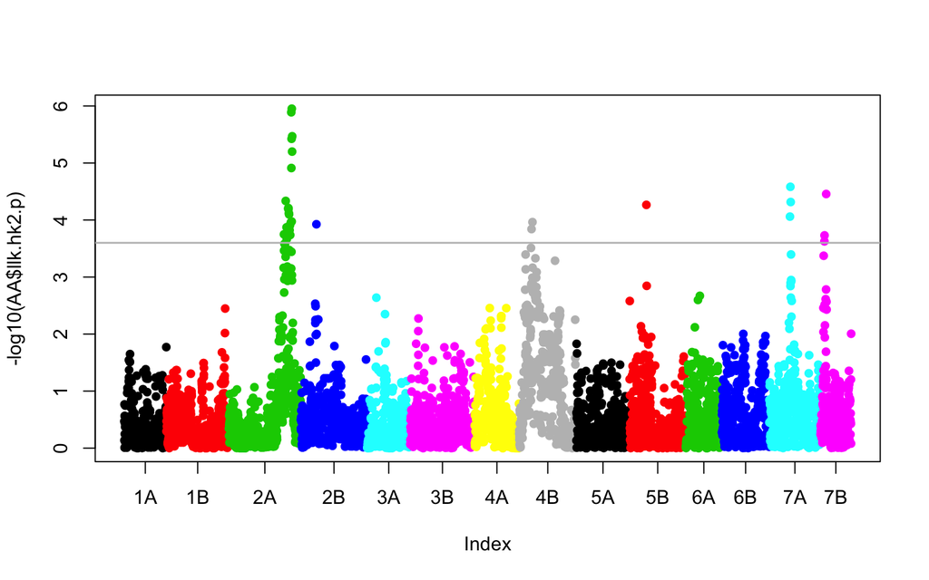

```r
# Merge LODs with the genetic map
AA=merge(map,data.frame( names(llk.hk2$p) , llk.hk2$p), by.x=1 , by.y=1, all.x=T)
AA=AA[order(AA$chr, AA$dist) , ]
AA=AA[!is.na(AA$llk.hk2.p) , ]
# And plot it
plot(-log10(AA$llk.hk2.p) , pch=20 , col=as.numeric(AA$chr) , cex=1.3, xaxt="n" )
abline(h=3.6, col="grey", lwd=1.5)
num=seq(1,nrow(AA))
num=aggregate(num, by=list(AA$chr), mean , na.rm=T)
axis(1, at=num[,2], labels=num[,1])
```

Summary of the significant markers:

```r
to_print=AA[-log10(AA$llk.hk2.p)>3.61 , ]
```

| snp | chr | dist | phyPos | llk.hk2.p |
| --- | --- | --- | --- | --- |
| Cluster_6910\|Contig1\|original@443 | 2A | 187.70 | 228653691 | 0.00 |
| Cluster_12235\|Contig1\|likelySeq@801 | 2A | 193.00 | 227692732 | 0.00 |
| Cluster_7136\|Contig2\|complementarySeq@411 | 2A | 194.50 | 232364993 | 0.00 |
| Cluster_2120\|Contig1\|original@910 | 2A | 197.20 | 225528958 | 0.00 |
| Cluster_8974\|Contig1\|original@1715 | 2A | 197.20 | 284006111 | 0.00 |
| Cluster_3936\|Contig1\|original@1314 | 2A | 202.60 | 311088300 | 0.00 |
| Cluster_10993\|Contig1\|original@362 | 2A | 204.10 | 228095048 | 0.00 |
| Cluster_13952\|Contig2\|complementarySeq@1067 | 2A | 204.30 | 221969353 | 0.00 |
| Cluster_13513\|Contig1\|complementarySeq@312 | 2A | 205.10 | 313190567 | 0.00 |
| Cluster_3035\|Contig10\|original@195 | 2A | 205.10 | NA | 0.00 |
| Cluster_14976\|Contig1\|original@377 | 2A | 207.70 | 234536369 | 0.00 |
| Cluster_14710\|Contig1\|original@326 | 2A | 208.80 | 235293388 | 0.00 |
| Cluster_1608\|Contig1\|original@289 | 2A | 208.80 | NA | 0.00 |
| Cluster_8810\|Contig1\|original@380 | 2A | 208.80 | NA | 0.00 |
| Cluster_10886\|Contig1\|original@355 | 2A | 210.60 | NA | 0.00 |
| Cluster_8278\|Contig2\|complementarySeq@339 | 2A | 211.20 | 236448384 | 0.00 |
| Cluster_8997\|Contig2\|original@993 | 2A | 214.70 | 237303655 | 0.00 |
| Cluster_6528\|Contig11\|original@342 | 2A | 214.90 | 238597423 | 0.00 |
| Cluster_5814\|Contig2\|original@2073 | 2A | 215.20 | 237140935 | 0.00 |
| Cluster_7309\|Contig1\|likelySeq@1027 | 2A | 215.20 | 317926629 | 0.00 |
| Cluster_7741\|Contig1\|original@390 | 2A | 215.20 | 237955082 | 0.00 |
| Cluster_14091\|Contig1\|original@109 | 2A | 218.80 | 240000045 | 0.00 |
| Cluster_14091\|Contig2\|original@276 | 2A | 218.80 | 240000045 | 0.00 |
| Cluster_10786\|Contig2\|original@200 | 2B | 117.80 | 44285664 | 0.00 |
| Cluster_3883\|Contig1\|complementarySeq@929 | 4B | 76.00 | 218448599 | 0.00 |
| Cluster_640\|Contig1\|complementarySeq@2159 | 4B | 78.40 | 126604664 | 0.00 |
| Cluster_8710\|Contig2\|original@224 | 5B | 99.80 | 183184647 | 0.00 |
| Cluster_11075\|Contig2\|original@652 | 7A | 115.50 | 54842723 | 0.00 |
| Cluster_5672\|Contig1\|likelySeq@976 | 7A | 116.90 | 54995067 | 0.00 |
| Cluster_4000\|Contig1\|likelySeq@264 | 7A | 117.70 | 30089594 | 0.00 |
| Cluster_1730\|Contig8\|original@239 | 7B | 31.70 | 6683044 | 0.00 |
| Cluster_11931\|Contig1\|complementarySeq@248 | 7B | 40.40 | 21919604 | 0.00 |
| Cluster_3623\|Contig2\|original@924 | 7B | 57.90 | 142360162 | 0.00 |

## Interaction effect.

We can also check for which marker the **interaction** effect was significant?

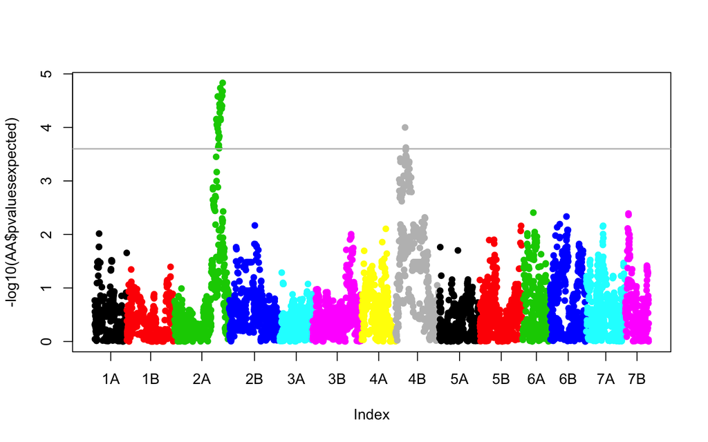

```r
#Compute 2 models: one with interaction, one without interaction
llk.hk_inter1 <-scanOne(y=Y$NV_blup_AR1, x=Y$year, vc=mod1, gdat=XNNA ,test="None")
llk.hk_inter2 <- scanOne(y=Y$NV_blup_AR1, vc=mod1, intcovar=Y$year, gdat=XNNA ,test="None")

# Find pvalue of each marker for interaction significance
diff_deviance <- llk.hk_inter2$p - llk.hk_inter1$p
pvaluesexpected=1-pchisq(diff_deviance, 1)

# Merge with map
AA=merge(map,data.frame( names(pvaluesexpected) , pvaluesexpected), by.x=1 , by.y=1, all.x=T)
AA=AA[order(AA$chr, AA$dist) , ]
AA=AA[!is.na(AA$pvaluesexpected) , ]

# Plot
plot(-log10(AA$pvaluesexpected) , pch=20 , col=as.numeric(AA$chr) , cex=1.3, xaxt="n" )
abline(h=3.6, col="grey", lwd=1.5)
num=seq(1,nrow(AA))
num=aggregate(num, by=list(AA$chr), mean , na.rm=T)
axis(1, at=num[,2], labels=num[,1])
```

# Elisa - NO blup normalization

## Load data

I load the genotyping matrix first.

```r
genotype<-read.table("/Users/holtz/Dropbox/Publi_Mosaique/DATA/DATA/GROUPED/genotypage.csv", sep = ";" , header = F, na.strings = "-")
genotype=as.matrix(genotype)
colnames(genotype)=genotype[1,]
genotype=as.data.frame(genotype[-1 , ])
names(genotype)[1]<-"geno"
print("--- Your genotyping matrix looks correct. Dimension of the matrix are :")
```

```
## [1] "--- Your genotyping matrix looks correct. Dimension of the matrix are :"
```

```r
print(dim(genotype))
```

```
## [1]  348 7342
```

```r
# I copy this matrix 2 times, since I read 2012 and 2015 together.
rownames(genotype)=genotype[,1]
genotype=genotype[,-1]
a=genotype ; rownames(a)=paste(rownames(a),"2012",sep="_")
b=genotype ; rownames(b)=paste(rownames(b),"2015",sep="_")
genotype=rbind(a,b)
```

Then the genetic map:

```r
map <- read.table("/Users/holtz/Dropbox/Publi_Mosaique/DATA/DATA/genetic_map.txt" , header=T , dec = ".", na.strings = "-" , check.names=F)
colnames(map) <- c("LG", "marqueur", "Distance","group_physique","Posi_physique")
rownames(map) <- map$marqueur
map$LG <- as.factor(map$LG)
print("--- Your genetic map looks correct. Dimension of the map are :")
```

```
## [1] "--- Your genetic map looks correct. Dimension of the map are :"
```

```r
print(dim(map))
```

```
## [1] 8568    5
```

```r
map=map[    , c(2,1,3,5)]
colnames(map)=c("snp","chr", "dist", "phyPos")
```

And finally the phenotyping matrix

```r
BLUP<-read.table("/Users/holtz/Dropbox/Publi_Mosaique/DATA/DATA/GROUPED/phenotypage.csv", header = TRUE, sep=";")
colnames(BLUP)[1]="geno"
print("--- Your Phenotyping matrix looks correct. Dimension of the matrix are :")
```

```
## [1] "--- Your Phenotyping matrix looks correct. Dimension of the matrix are :"
```

```r
print(dim(BLUP))
```

```
## [1] 396   6
```

```r
# Put ELisa2012 and 2015 together
a=BLUP[, c(1,3)] ; a$year="2012" ; colnames(a)=c("geno", "Elisa_blup_AR1","year") ; #a[,2]=a[,2]/0.745  #
#a[,2]=ifelse(substr(a$geno, 1,2)=="TT", a[,2]/0.08373045 , a[,2]/ 0.07145543)
b=BLUP[, c(1,5)] ; b$year="2015" ; colnames(b)=c("geno", "Elisa_blup_AR1", "year") ; #b[,2]=b[,2]/1.2   #
#b[,2]=ifelse(substr(b$geno, 1,2)=="TT", b[,2]/0.14488006 , a[,2]/0.13135315)
BLUP=rbind(a,b)
rownames(BLUP)=paste( BLUP[,1], BLUP$year,sep="_")
BLUP=BLUP[,-1]
# Note: On peut garder les blups tels quels / ou les pondéré par la variance génet de chaque année moyennée sur les 2 pops / ou par la variance génet de chaque année et chaque pop.
```

## Prepare data

We need to have genotype and phenotype in the same order:

```r
Y=na.omit(BLUP)
Y=Y[which(rownames(Y)%in%rownames(genotype)) , ]
genotype=genotype[which(rownames(genotype)%in%rownames(Y)) , ]
genotype=genotype[ match(rownames(Y),rownames(genotype)) , ]
```

## Calculate kinship matrix

```r
# missing data
set.seed(123)
XNNA=genotype
my_fun=function(x){length(x[x=="A" & !is.na(x) ])/length(!is.na(x)) }
prop=apply(XNNA , 2 , my_fun)
for(i in c(1:ncol(XNNA))){
    aa=XNNA[,i][is.na(XNNA[,i])]
    bb=rbinom(length(aa),1,prob=prop[i])
    XNNA[,i][is.na(XNNA[,i])]=c("B","A")[bb+1]
    }

# Change "A" to "AA"
XNNA=as.matrix(XNNA)
XNNA[which(XNNA=="A")]<-"AA"
XNNA[which(XNNA=="B")]<-"BB"

# Kinship matrix
K<-genMatrix(XNNA)

# I = identity matrix
I<-diag(nrow(Y))
```

## Markers effect

We compute a complete modele in QTLRel including year effect, marker effect and interaction between both.This model is computed marker per marker using the scanOne function. We compare the likelihood of this model with the model that does not include any marker, what gives us the marker effect trough its LOD score.

```r
mod1<-estVC(y=Y$Elisa_blup_AR1, x=Y$year, v=list(AA=K$AA,DD=NULL,HH=NULL,AD=NULL,MH=NULL,EE=I))
llk.hk2 <- scanOne(y=Y$Elisa_blup_AR1, vc=mod1, intcovar=Y$year, gdat=XNNA ,test="Chisq")
```

Manhattan plot to visualize the effect of each marker.

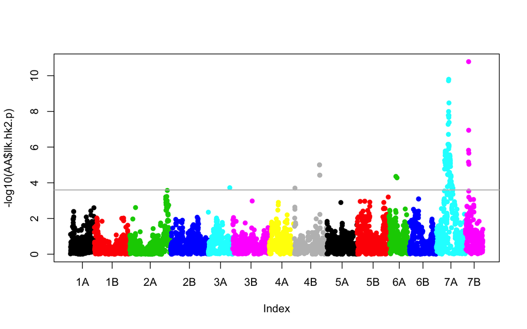

```r
# Merge LODs with the genetic map
AA=merge(map,data.frame( names(llk.hk2$p) , llk.hk2$p), by.x=1 , by.y=1, all.x=T)
AA=AA[order(AA$chr, AA$dist) , ]
AA=AA[!is.na(AA$llk.hk2.p) , ]
# And plot it
plot(-log10(AA$llk.hk2.p) , pch=20 , col=as.numeric(AA$chr) , cex=1.3, xaxt="n" )
abline(h=3.6, col="grey", lwd=1.5)
num=seq(1,nrow(AA))
num=aggregate(num, by=list(AA$chr), mean , na.rm=T)
axis(1, at=num[,2], labels=num[,1])
```

Summary of the significant markers:

```r
to_print=AA[-log10(AA$llk.hk2.p)>3.61 , ]
```

| snp | chr | dist | phyPos | llk.hk2.p |
| --- | --- | --- | --- | --- |
| Cluster_619\|Contig1\|original@832 | 3A | 201.20 | 172452668 | 0.00 |
| Cluster_1731\|Contig11\|original@1198 | 4B | 2.20 | 172479391 | 0.00 |
| Cluster_156\|Contig1\|original@1139 | 4B | 125.90 | 286159851 | 0.00 |
| Cluster_2107\|Contig1\|original@272 | 4B | 125.90 | 265310050 | 0.00 |
| Cluster_2215\|Contig2\|original@863 | 4B | 125.90 | NA | 0.00 |
| Cluster_825\|Contig2\|likelySeq@357 | 4B | 125.90 | 288494866 | 0.00 |
| Cluster_3689\|Contig1\|likelySeq@477 | 6A | 74.30 | 124315721 | 0.00 |
| Cluster_4521\|Contig1\|original@276 | 6A | 90.00 | 176352357 | 0.00 |
| Cluster_595\|Contig5\|likelySeq@290 | 7A | 90.80 | 27163704 | 0.00 |
| Cluster_15306\|Contig2\|complementarySeq@768 | 7A | 91.70 | 12569805 | 0.00 |
| Cluster_9995\|Contig2\|complementarySeq@174 | 7A | 93.50 | NA | 0.00 |
| Cluster_10035\|Contig4\|original@278 | 7A | 94.00 | 1805115 | 0.00 |
| Cluster_12589\|Contig2\|likelySeq@1037 | 7A | 94.00 | 25209491 | 0.00 |
| Cluster_1293\|Contig1\|original@351 | 7A | 94.00 | 27025106 | 0.00 |
| Cluster_14\|Contig1066\|original@502 | 7A | 94.00 | NA | 0.00 |
| Cluster_14\|Contig1373\|original@268 | 7A | 94.00 | NA | 0.00 |
| Cluster_14\|Contig329\|complementarySeq@2088 | 7A | 94.00 | NA | 0.00 |
| Cluster_14\|Contig730\|original@366 | 7A | 94.00 | NA | 0.00 |
| Cluster_16238\|Contig2\|likelySeq@1019 | 7A | 94.00 | 17761623 | 0.00 |
| Cluster_1730\|Contig15\|likelySeq@1256 | 7A | 94.00 | NA | 0.00 |
| Cluster_179\|Contig1\|original@2502 | 7A | 95.50 | 22698555 | 0.00 |
| Cluster_179\|Contig4\|original@3123 | 7A | 96.20 | 22698555 | 0.00 |
| Cluster_179\|Contig5\|original@399 | 7A | 96.20 | 22698555 | 0.00 |
| Cluster_14\|Contig340\|original@247 | 7A | 96.40 | 28050689 | 0.00 |
| Cluster_10130\|Contig1\|likelySeq@473 | 7A | 97.90 | 5277810 | 0.00 |
| Cluster_10163\|Contig1\|likelySeq@448 | 7A | 106.30 | 31560066 | 0.00 |
| Cluster_9435\|Contig2\|original@897 | 7A | 107.60 | 34129273 | 0.00 |
| Cluster_1874\|Contig2\|original@90 | 7A | 110.70 | 32550765 | 0.00 |
| Cluster_17712\|Contig1\|original@838 | 7A | 112.80 | NA | 0.00 |
| Cluster_14534\|Contig1\|original@91 | 7A | 113.40 | 28190603 | 0.00 |

[output cut: 60 more lines]

## Interaction effect.

We can also check for which marker the **interaction** effect was significant?

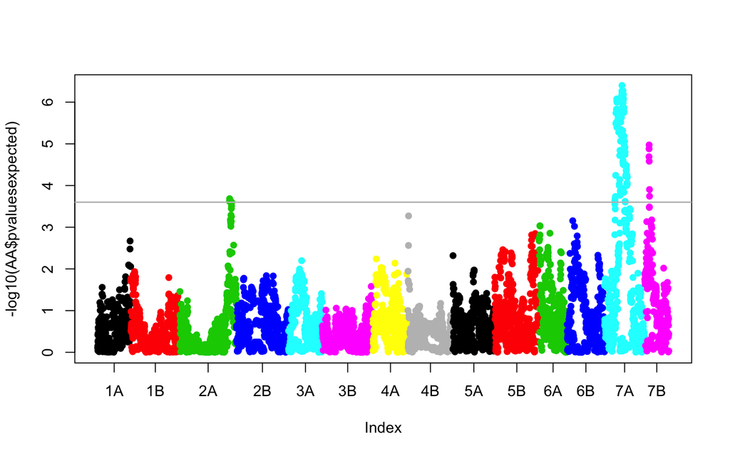

```r
#Compute 2 models: one with interaction, one without interaction
llk.hk_inter1 <-scanOne(y=Y$Elisa_blup_AR1, x=Y$year, vc=mod1, gdat=XNNA ,test="None")
llk.hk_inter2 <- scanOne(y=Y$Elisa_blup_AR1, vc=mod1, intcovar=Y$year, gdat=XNNA ,test="None")

# Find pvalue of each marker for interaction significance
diff_deviance <- llk.hk_inter2$p - llk.hk_inter1$p
pvaluesexpected=1-pchisq(diff_deviance, 1)

# Merge with map
AA=merge(map,data.frame( names(pvaluesexpected) , pvaluesexpected), by.x=1 , by.y=1, all.x=T)
AA=AA[order(AA$chr, AA$dist) , ]
AA=AA[!is.na(AA$pvaluesexpected) , ]

# Plot
plot(-log10(AA$pvaluesexpected) , pch=20 , col=as.numeric(AA$chr) , cex=1.3, xaxt="n" )
abline(h=3.6, col="grey", lwd=1.5)
num=seq(1,nrow(AA))
num=aggregate(num, by=list(AA$chr), mean , na.rm=T)
axis(1, at=num[,2], labels=num[,1])
```

Yan Holtz

December 2016